# Lab02

Ryan McNally

9/14/2021

```r
library(classdata)
data(choco)
str(choco)
```

```
## Classes 'tbl_df', 'tbl' and 'data.frame':    2452 obs. of  13 variables:
##  $ REF               : num  2454 2458 2454 2542 2546 ...
##  $ Company           : chr  "5150" "5150" "5150" "5150" ...
##  $ Location          : chr  "U.S.A." "U.S.A." "U.S.A." "U.S.A." ...
##  $ ReviewDate        : num  2019 2019 2019 2021 2021 ...
##  $ CountryBeanOrigin : chr  "Tanzania" "Dominican Republic" "Madagascar" "Fiji" ...
##  $ SpecificBeanOrigin: chr  "Kokoa Kamili, batch 1" "Zorzal, batch 1" "Bejofo Estate, batch 1" "Matasawalevu, batch 1" ...
##  $ Ingredients       : chr  "3- B,S,C" "3- B,S,C" "3- B,S,C" "3- B,S,C" ...
##  $ Characteristics1  : chr  "rich cocoa" "cocoa" "cocoa" "chewy" ...
##  $ Characteristics2  : chr  "fatty" "vegetal" "blackberry" "off" ...
##  $ Characteristics3  : chr  "bready" "savory" "full body" "rubbery" ...
##  $ Characteristics4  : chr  NA NA NA NA ...
##  $ Rating            : num  3.25 3.5 3.75 3 3 3.25 3.5 3.5 3.75 2.75 ...
##  $ CocoaPercent      : num  76 76 76 68 72 80 68 70 63 70 ...
```

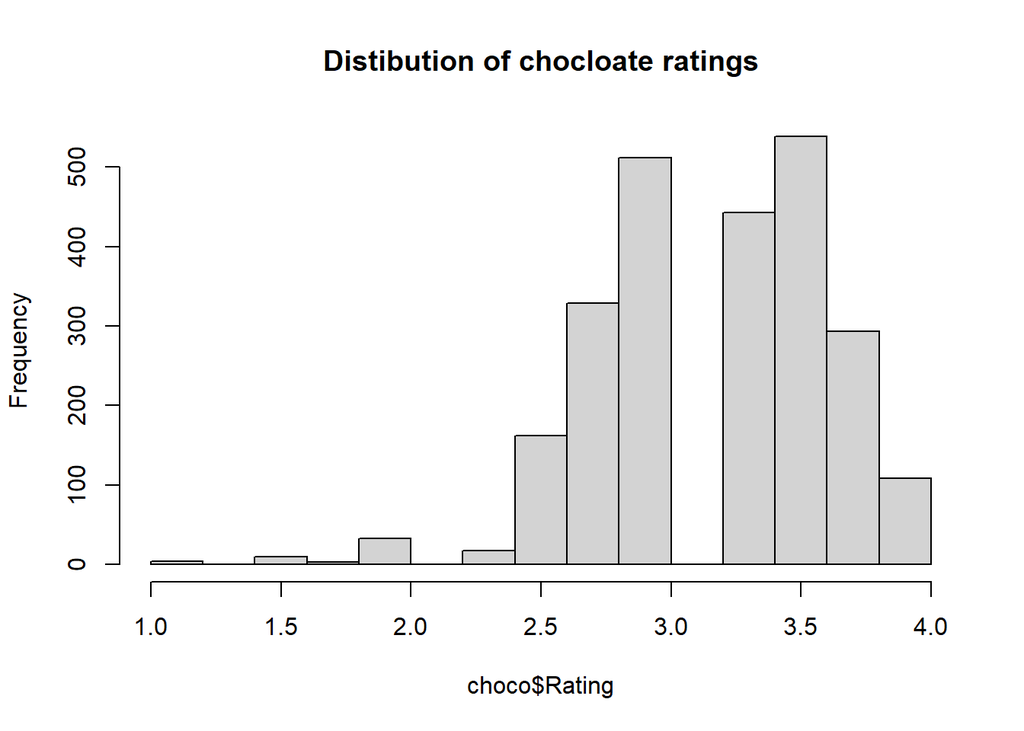

```r
hist(choco$Rating, main="Distibution of chocloate ratings")
```

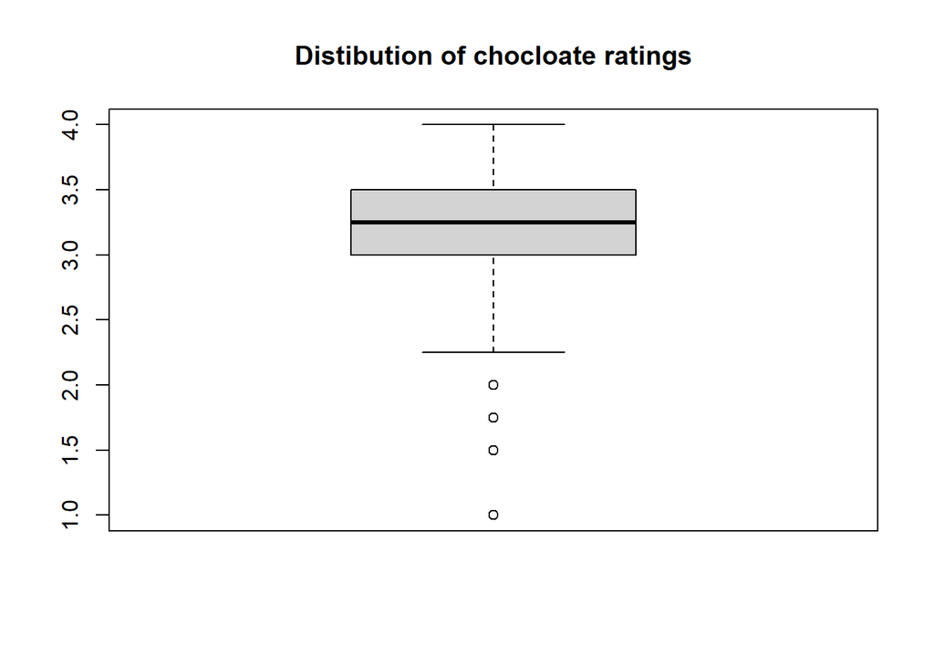

```r
boxplot(choco$Rating, main="Distibution of chocloate ratings")
```

**As shown by the boxplot bellow, there are some outliers in this data. All of the points on the boxplot that are outside of the box and whisker plot are considered outliers. The histogram bellow also clearly shows that the data is left skewed.**

2. How does the number of ratings depend on the country of bean origin?

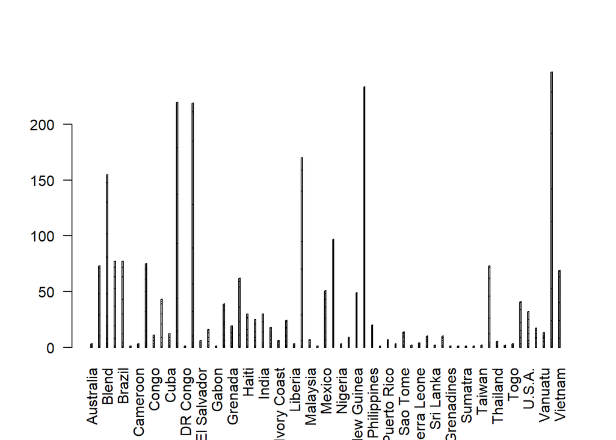

```r
x<- table(choco$Rating, choco$CountryBeanOrigin)
barplot(x, las=2,space=5)
```

3. Do ratings depend on the percentage of cocao?

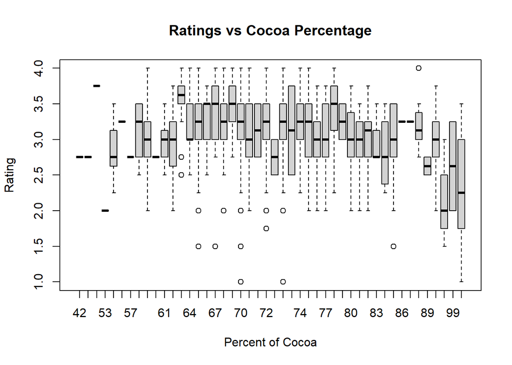

```r
boxplot(choco$Rating ~ factor(choco$CocoaPercent), main="Ratings vs Cocoa Percentage", xlab="Percent of Cocoa", ylab="Rating")
```

How do different bean origins compare in terms of the flavor of chocolates?

```r
library(tidyverse)
```

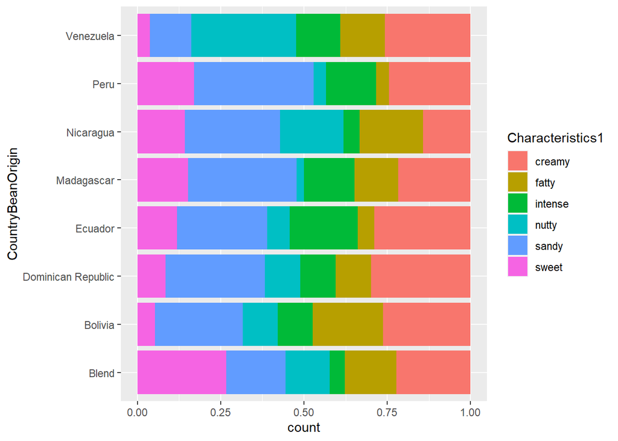

```r
char1 <- table(choco$Characteristics1)
char1_sorted <- char1[char1 > 70]
choco_sorted <- filter(choco, Characteristics1 %in% names(char1_sorted))
country_sorted <- table(choco$CountryBeanOrigin) %>%
  sort(decreasing = TRUE) %>%
  head(8)
choco %>%
  filter(Characteristics1 %in% names(char1_sorted)) %>%
  filter(CountryBeanOrigin %in% names(country_sorted)) %>%
  ggplot() +
  geom_bar(aes(x = CountryBeanOrigin, fill = Characteristics1), position = 'fill') + coord_flip()
```

```r
tapply(choco$Rating, choco$CountryBeanOrigin, summary) %>%
  head(5)
```

```
## $Australia
##    Min. 1st Qu.  Median    Mean 3rd Qu.    Max.
##    2.75    3.00    3.25    3.25    3.50    3.75
##
## $Belize
##    Min. 1st Qu.  Median    Mean 3rd Qu.    Max.
##   2.500   3.000   3.250   3.236   3.500   4.000
##
## $Blend
##    Min. 1st Qu.  Median    Mean 3rd Qu.    Max.
##   1.000   2.750   3.000   3.037   3.500   4.000
##
## $Bolivia
##    Min. 1st Qu.  Median    Mean 3rd Qu.    Max.
##   2.000   3.000   3.250   3.175   3.500   4.000
##
## $Brazil
##    Min. 1st Qu.  Median    Mean 3rd Qu.    Max.
##   1.750   3.000   3.250   3.263   3.500   4.000
```

**As shown in the graph above, beans from different countries of origin have different flavor profiles. From this alone, we can not conclude that beans from some places are better than others**

“1. I would like to see is if the rating of cocoa beans have changed over time.”

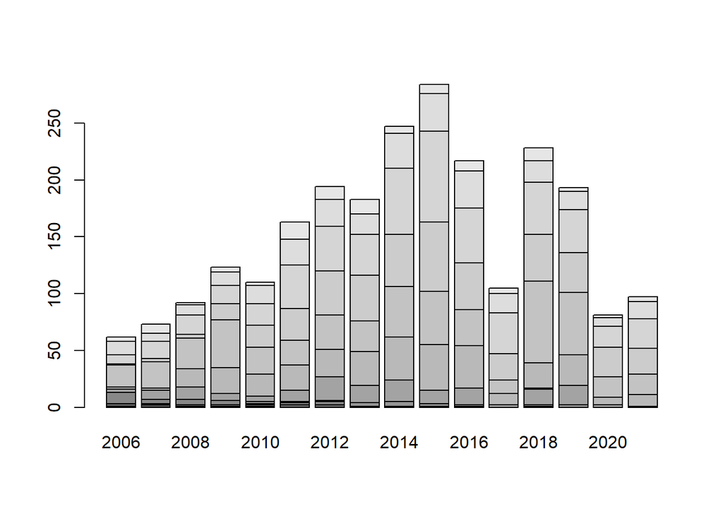

```r
now <- table(choco$Rating, choco$ReviewDate)
barplot(now)
```

```r
cor(now)
```

```
##           2006      2007      2008      2009      2010      2011      2012
## 2006 1.0000000 0.8398903 0.7525739 0.7234466 0.5740098 0.4482576 0.4441503
## 2007 0.8398903 1.0000000 0.8520591 0.7856873 0.6565800 0.6237383 0.6354234
## 2008 0.7525739 0.8520591 1.0000000 0.9217150 0.8118948 0.6676552 0.7016912
## 2009 0.7234466 0.7856873 0.9217150 1.0000000 0.8950149 0.6801963 0.7251315
## 2010 0.5740098 0.6565800 0.8118948 0.8950149 1.0000000 0.8973023 0.9162667
## 2011 0.4482576 0.6237383 0.6676552 0.6801963 0.8973023 1.0000000 0.9588856
## 2012 0.4441503 0.6354234 0.7016912 0.7251315 0.9162667 0.9588856 1.0000000
## 2013 0.3263897 0.5442154 0.6564858 0.7241794 0.9190508 0.9512751 0.9745345
## 2014 0.4699941 0.6442710 0.7659688 0.7833924 0.9573518 0.9569358 0.9735924
## 2015 0.4133194 0.6004943 0.6771413 0.7066787 0.9140917 0.9621986 0.9525952
## 2016 0.4293474 0.5674014 0.7093181 0.7360948 0.9493374 0.9734756 0.9693774
## 2017 0.3636119 0.5305811 0.5260614 0.5261509 0.8021256 0.9457226 0.8899507
## 2018 0.6675660 0.8497637 0.8411098 0.9159444 0.9081139 0.8098002 0.8603909
## 2019 0.5959432 0.7821755 0.8687794 0.9230086 0.9448787 0.8309460 0.8998032
```

[output cut: 36 more lines]

**There is no clear correlation between year and rating.**

2. I would like to explore and see is if the cocoa percent is dependent on the country of origin of the bean.

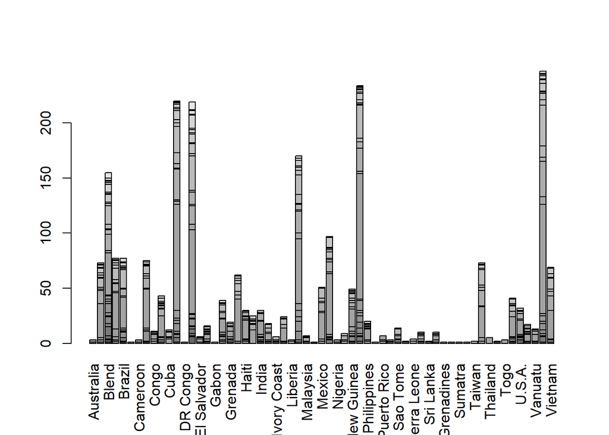

```r
dep <- table(choco$CocoaPercent, choco$CountryBeanOrigin)
#cor(dep)
barplot(dep, las=3)
```